# Mexican Peppers

Robert Myles McDonnell

2017-09-29

I was having a look at [Mike Bostock’s Municipalities of Mexico visualization](https://bl.ocks.org/mbostock/c57be63169694093cca028194068ea3b) when I thought it would be *so* cool to fill those municipalities with info on peppers and chiles and their various levels of hotness, all in nice pepper colours (I love spicy peppers!). Well, I wasn’t quite able to get data on municipalities (if you know where I could get these data, please let me know), but I managed to scrape together some info on state-level pepper production, or at least the main pepper produced in each category.[^1]

I used R’s ggplot2 package (along with a few others) to quickly visualize the data[^2]. Here’s the code, in case you’d like to recreate it:

```r
library(sf)
library(dplyr)
library(ggplot2)
library(extrafont)
loadfonts()

mex <-st_read("C://Users/robert.m.mcdonnell/Downloads/MexicoStates/Entidades_2010_5.shp") %>%
  mutate(state = as.character(NOM_ENT),
         state_id = as.numeric(CVE_ENT),
         state =  case_when(
                         CVE_ENT == 15 ~ "Mexico",
                         CVE_ENT == 16 ~ "Michoacan de Ocampo",
                         CVE_ENT == 21 ~ "Queretaro",
                         CVE_ENT == 24 ~ "San Luis Potosi",
                         CVE_ENT == 19 ~ "Nuevo Leon",
                         CVE_ENT == 31 ~ "Yucatan",
                         TRUE ~ state),
         chili = case_when(
           state %in% c("Baja California", "Chihuahua", "Nuevo Leon",
                        "Coahuila de Zaragoza", "Nayarit", "Quintana Roo",
                        "Campeche", "Chiapas", "Michoacan de Ocampo", "Jalisco",
                        "Colima", "Sonora", "Tabasco", "Queretaro") ~ "Jalapeño",
           state %in% c("Tamaulipas", "Tlaxcala", "Guerrero", "Puebla", "Mexico",
                        "San Luis Potosi", "Morelos",
                        "Veracruz de Ignacio de la Llave", "Hidalgo") ~ "Serrano",
           state %in% c("Baja California Sur", "Aguascalientes", "Durango",
                        "Guanajuato") ~ "Poblano",
           state %in% c("Zacatecas", "Sinaloa") ~ "Morrón",
           state %in% c("Oaxaca", "Yucatan") ~ "Various",
           state == "Distrito Federal" ~ "Other"),
         Scoville = case_when(
           chili == "Jalapeño" ~ 3750,
           chili == "Serrano" ~ 14000,
           chili == "Poblano" ~ 1500,
           chili == "Various" ~ 20000,
           chili == "Morrón" ~ 0,
           TRUE ~ 0))
```

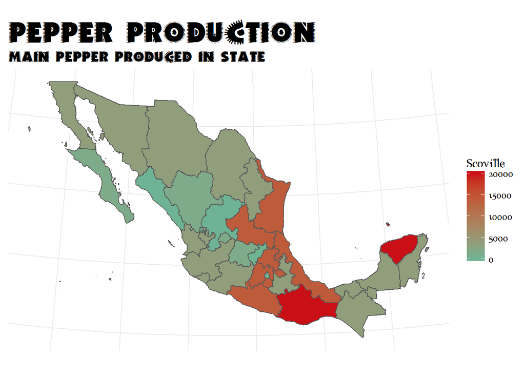

```r
ggplot(mex) +
  geom_sf(aes(fill = Scoville)) +
  scale_fill_continuous(low = "#6EB394", high = "#CB0F17") +
  theme_minimal() +
  labs(title = "Pepper Production", subtitle = "Main pepper produced in state") +
  theme(text = element_text(family = "Mayan"),
        plot.title = element_text(family = "JICAMA ", size = 24),
        plot.subtitle = element_text(family = "JICAMA ", size = 12),
        axis.text = element_blank())
```

Wow, gotta love those fonts.[^3]  
Ok, so now we have a rough idea of how things might look, time to fire up d3 with this dataset.

[^1]: The sources were a combination of [here](http://www.sagarpa.gob.mx/Delegaciones/nayarit/boletines/Paginas/BNSAGENE052017.aspx), [here](http://www.mexconnect.com/pages/map) and [here](http://infosiap.siap.gob.mx/images/stories/infogramas/100705-monografia-chile.pdf)
[^2]: the shapefiles are available from the urls in the bash script of Mike Bostock’s image, linked to above.
[^3]: ‘Jicama’ (title) can be seen [here](https://www.dafont.com/pt/jicama.font) and ‘Mayan’ (legend) [here](https://www.dafont.com/mayan2.font)